# Quality of Weight Lifting Exercises

Joe Bragg

Monday, January 12, 2015

## Executive Summary

This is an analysis of the [Human Activity Recognition Weight Lifting Exercises Dataset](http://groupware.les.inf.puc-rio.br/har#weight_lifting_exercises) which classifies Unilateral Dumbbell Biceps Curls performed by 6 participants as correctly performed (Class A), throwing the elbows to the front (Class B), lifting the dumbbell only halfway (Class C), lowering the dumbbell only halfway (Class D) and throwing the hips to the front (Class E). The below machine learning analysis attempts to predict these classifications based on measurements from sensors on the belt, arm and the weight itself.

The data includes a training data set (pml-training.csv) and a testing data set (pml-testing.csv).

This analysis concluded that Stochastic Gradient Boosting (gbm) provided the greatest Accuracy of predictions against the observed results.

## Analysis

```r
if(!file.exists("pml-training.csv")){
        download.file("http://d396qusza40orc.cloudfront.net/predmachlearn/pml-training.csv",destfile="pml-training.csv")
}
origdata<-read.csv("pml-training.csv")
dim(origdata)
```

```
## [1] 19622   160
```

This data frame is quite large with 19622 rows and 160 columns.

The data is actually a combination of raw sensor data and statistical summary data at the end of each sliding window. The raw data includes axial fields for roll, pitch & yaw, as well as gyro, acceleration and magnetic data. The summary data includes mean, variance, standard deviation, max, min, amplitude, kurtosis and skewness of the sensor data in the sliding windows.

The summary data includes numerous NAs as they are only calculated at the end of the sliding windows and they include divide by 0 entries. Taking a peek at the “pml-testing.csv” data none of the entries include summary data nor do they seem to be split by time series. For these reasons, the summary data will not be used in this analysis.

Here we remove those summary variables and include only the raw sensor data and the observed “classe” field. This results in a data table with 19,622 rows and 49 variables.

```r
sensordata<-origdata[,c(160,grep("^roll|^pitch|^yaw|^gyros|^accel|^magnet",
                names(origdata)))]
```

We checked to determine if there is any opportunity to further reduce the number variables. We checked for Near Zero Variation of the variables but none existed. Below is a heat map of the variable correlations but it seems only a few have any significant correlation (>0.8) off the diagonal.

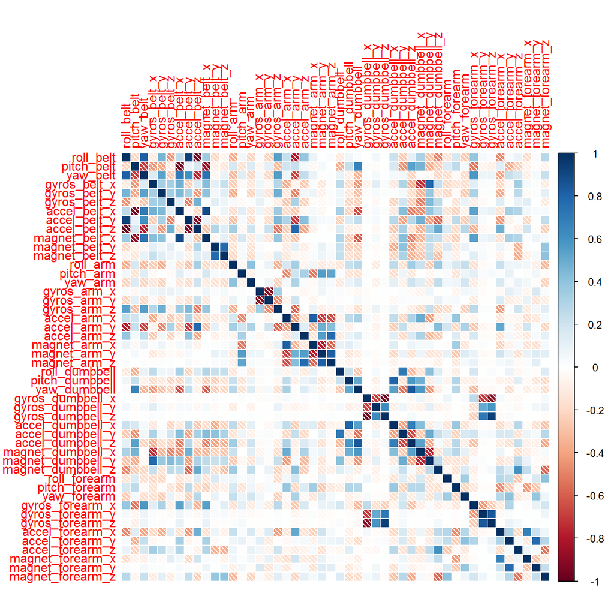

```r
library(corrplot)
trainCor <- cor(sensordata[,-1])
corrplot(trainCor, method = "shade")
```

We will now split the sensor data into a training and test/quiz set.

```r
library(caret)
inTrain <- createDataPartition(y=sensordata$classe,p=0.6, list=FALSE)
training <- sensordata[inTrain,]
testing <- sensordata[-inTrain,]
```

After testing a few random tree models with and without preprocessing, it seems Stochastic Gradient Boosting (gbm) provided the greatest Accuracy against the observed “classe” field in the training data and in the cross validation test/quiz data. (Note: Messages are suppressed to inhibit lists of packages loading and other extraneous information.)

```r
set.seed(1234)
modFit <- suppressMessages(train(classe ~ ., method="gbm",data=training,verbose=FALSE))
```

Here is the model fit against the training data and the resulting Accuracy. See Appendix for details.

```r
trainpred<-suppressMessages(predict(modFit,newdata=training))
trainCM<-confusionMatrix(trainpred,training$classe)
trainCM$overall["Accuracy"]
```

```
##  Accuracy
## 0.9742697
```

The In Sample Error is 1-Overall Training Accuracy, therefore in the above model it is 0.0257.

Here is the model fit against the test/quiz data and the resulting Accuracy. See Appendix for details.

```r
testpred<-predict(modFit,newdata=testing)
testCM<-confusionMatrix(testpred,testing$classe)
testCM$overall["Accuracy"]
```

```
##  Accuracy
## 0.9598522
```

The Out of Sample Error is 1-Overall Testing Accuracy, therefore in the above model it is 0.0401 which is greater than the In Sample Error above so we don’t seem to be over fitting.

The results of this model’s predictions against the actual test data (pml-testing.csv) gave 20 out of 20 correct predictions.

## References

Velloso, E.; Bulling, A.; Gellersen, H.; Ugulino, W.; Fuks, H. [Qualitative Activity Recognition of Weight Lifting Exercises](http://groupware.les.inf.puc-rio.br/work.jsf?p1=11201). Proceedings of 4th International Conference in Cooperation with SIGCHI (Augmented Human ’13) . Stuttgart, Germany: ACM SIGCHI, 2013.

Read more: http://groupware.les.inf.puc-rio.br/har#wle_paper_section#ixzz3PEJce7CT

## Appendix

Below are the details of the final training and testing Confusion Matrices.

```r
trainCM
```

```
## Confusion Matrix and Statistics
##
##           Reference
## Prediction    A    B    C    D    E
##          A 3316   58    0    0    2
##          B   22 2182   40   10    8
##          C    8   39 1994   49   14
##          D    2    0   16 1861   21
##          E    0    0    4   10 2120
##
## Overall Statistics
##
##                Accuracy : 0.9743
##                  95% CI : (0.9712, 0.9771)
##     No Information Rate : 0.2843
##     P-Value [Acc > NIR] : < 2.2e-16
##
##                   Kappa : 0.9674
##  Mcnemar's Test P-Value : 1.505e-11
##
## Statistics by Class:
##
##                      Class: A Class: B Class: C Class: D Class: E
## Sensitivity            0.9904   0.9574   0.9708   0.9642   0.9792
## Specificity            0.9929   0.9916   0.9887   0.9960   0.9985
## Pos Pred Value         0.9822   0.9646   0.9477   0.9795   0.9934
## Neg Pred Value         0.9962   0.9898   0.9938   0.9930   0.9953
## Prevalence             0.2843   0.1935   0.1744   0.1639   0.1838
## Detection Rate         0.2816   0.1853   0.1693   0.1580   0.1800
## Detection Prevalence   0.2867   0.1921   0.1787   0.1613   0.1812
## Balanced Accuracy      0.9917   0.9745   0.9797   0.9801   0.9889
```

```r
testCM
```

```
## Confusion Matrix and Statistics
##
##           Reference
## Prediction    A    B    C    D    E
##          A 2186   62    0    0    1
##          B   29 1412   40    4   11
##          C   13   43 1310   41    9
##          D    2    1   16 1224   22
##          E    2    0    2   17 1399
##
## Overall Statistics
##
##                Accuracy : 0.9599
##                  95% CI : (0.9553, 0.9641)
##     No Information Rate : 0.2845
##     P-Value [Acc > NIR] : < 2.2e-16
##
##                   Kappa : 0.9492
##  Mcnemar's Test P-Value : 1.828e-08
##
## Statistics by Class:
##
##                      Class: A Class: B Class: C Class: D Class: E
## Sensitivity            0.9794   0.9302   0.9576   0.9518   0.9702
## Specificity            0.9888   0.9867   0.9836   0.9938   0.9967
## Pos Pred Value         0.9720   0.9439   0.9251   0.9676   0.9852
## Neg Pred Value         0.9918   0.9833   0.9910   0.9906   0.9933
## Prevalence             0.2845   0.1935   0.1744   0.1639   0.1838
## Detection Rate         0.2786   0.1800   0.1670   0.1560   0.1783
## Detection Prevalence   0.2866   0.1907   0.1805   0.1612   0.1810
## Balanced Accuracy      0.9841   0.9584   0.9706   0.9728   0.9835
```